# Assignment 4: Spatial Predictive Analysis

311 Violations In Chicago

Author

Joey Cahill

Published

December 6, 2025

# Assignment 4

This analysis will apply 311 Data from the City of Chicago to create a spatial predictive model which will be used to asses crime risk in neighborhoods.

## Introduction

The data that will be explored in this analysis are 311 Service Requests from the City of Chicago for Vacant and Abandoned Buildings Reported. Vacant buildings can be indicative of a number of things including poverty, shifting development, and deindustrialization. These are factors that are positively associated with crime rates and marginalized communities that at susceptible to over-policing. It is my hypothesis that areas with high vacancy rates will have increased crime rates. This dataset includes several suplementary features that include indicators for gang activity, homelessness, and reasons for vacancy such as fire or hazardous conditions. Some of these features have potential to be heavily biased by underlying facotors in the method of reporting, but they will provide further clarity on the nature of the buildings that are observed.

## Data Exploration

### Setup

Here we load the necessary R packages for the analysis, set themes and set formatting.

```r
# Packages
library(tidyverse)      # Data manipulation
library(sf)             # Spatial operations
library(here)           # Relative file paths
library(viridis)        # Color scales
library(terra)          # Raster operations (replaces 'raster')
library(spdep)          # Spatial dependence
library(FNN)            # Fast nearest neighbors
library(MASS)           # Negative binomial regression
library(patchwork)      # Plot composition (replaces grid/gridExtra)
library(knitr)          # Tables
library(kableExtra)     # Table formatting
library(classInt)       # Classification intervals
library(here)

# Sub-Packages
library(spatstat.geom)    # Spatial geometries
library(spatstat.explore) # Spatial exploration/KDE

# No Scientific Notation
options(scipen = 999)
```

```r
# Visualization themes
theme_crime <- function(base_size = 12) {
  theme_minimal(base_size = base_size) +
    theme(
      panel.background = element_rect(fill = "gray95", color = NA),
      panel.grid.major = element_line(color = "white"),

      # Titles
      plot.title = element_text(face = "bold", size = base_size + 2),
      plot.subtitle = element_text(color = "gray40", size = base_size),

      # Legend
      legend.position = "bottom",

      # REMOVE axes text, ticks, titles
      axis.text  = element_blank(),
      axis.ticks = element_blank(),
      axis.title = element_blank()
    )
}


# Default theme
theme_set(theme_crime())

cat("✓ All packages loaded successfully!\n")
```

```
✓ All packages loaded successfully!
```

```r
cat("✓ Working directory:", getwd(), "\n")
```

```
✓ Working directory: C:/Users/jcahi/OneDrive/Desktop/MUSA 5080/Portfolio/labs/lab_4
```

Here we load spatial boundaries for Chicago including Police Districts, Beats, the overall city boundaries.This will allow better visualize the areas in which the analysis is conducted.

```r
# Load police districts (used for spatial cross-validation)
policeDistricts <-
  st_read("https://data.cityofchicago.org/api/geospatial/24zt-jpfn?method=export&format=GeoJSON") %>%
  st_transform('ESRI:102271') %>%
  dplyr::select(District = dist_num)
# Load police beats (smaller administrative units)
policeBeats <-
  st_read("https://data.cityofchicago.org/api/geospatial/n9it-hstw?method=export&format=GeoJSON") %>%
  st_transform('ESRI:102271') %>%
  dplyr::select(Beat = beat_num)
# Load Chicago boundary
chicagoBoundary <-
  st_read("https://raw.githubusercontent.com/urbanSpatial/Public-Policy-Analytics-Landing/master/DATA/Chapter5/chicagoBoundary.geojson") %>%
  st_transform('ESRI:102271')
cat("✓ Loaded spatial boundaries\n")
```

```
✓ Loaded spatial boundaries
```

```r
cat("  - Police districts:", nrow(policeDistricts), "\n")
```

```
  - Police districts: 25
```

```r
cat("  - Police beats:", nrow(policeBeats), "\n")
```

```
  - Police beats: 277
```

Next, Burglary Data is loaded and will be used as an analog for criminal activity. Considerations for this data include recognizing that it has potential to be biased on systemic factors like over-reporting and demographic discrimination. High crime areas heavily coincide with impoverished communities that are likely to be over represented in police records.

```r
# Load Burglary data
burglaries <- st_read("data/burglaries.shp") %>%
  st_transform('ESRI:102271')
# Data checks
cat("\n✓ Loaded burglary data\n")
```

```
✓ Loaded burglary data
```

```r
cat("  - Number of burglaries:", nrow(burglaries), "\n")
```

```
  - Number of burglaries: 7482
```

```r
cat("  - CRS:", st_crs(burglaries)$input, "\n")
```

```
  - CRS: ESRI:102271
```

```r
cat("  - Date range:", min(burglaries$date, na.rm = TRUE), "to",
    max(burglaries$date, na.rm = TRUE), "\n")
```

```
  - Date range: Inf to -Inf
```

A dataset of 311 calls reporting Vacant or Abandoned buildings will be used to create predictor variables. This dataset includes details of location (address, police boundaries, etc.) and building descriptors (nature of abandonment and activity reported).

```r
vacant_buildings <- read_csv(
  "data/311_Service_Requests_-_Vacant_and_Abandoned_Buildings_Reported_-_Historical_20251110.csv"
) %>%
  filter(!is.na(LATITUDE), !is.na(LONGITUDE)) %>%
  st_as_sf(coords = c("LONGITUDE", "LATITUDE"), crs = 4326) %>%
  st_transform('ESRI:102271')

cat("✓ Loaded vacant + abandoned buildings data\n")
```

```
✓ Loaded vacant + abandoned buildings data
```

```r
cat("  - Number of calls:", nrow(vacant_buildings), "\n")
```

```
  - Number of calls: 65073
```

### Vacant housing data view

Summary statistics and basic view of the Vacant Buildings dataset is generated to make decisions on which variables to include in analysis.

```r
# Dropping Geometry for cleaner view of stats
vb_df <- vacant_buildings %>% st_drop_geometry()

summary(vb_df)
```

```
 SERVICE REQUEST TYPE SERVICE REQUEST NUMBER DATE SERVICE REQUEST WAS RECEIVED
 Length:65073         Length:65073           Length:65073
 Class :character     Class :character       Class :character
 Mode  :character     Mode  :character       Mode  :character




 LOCATION OF BUILDING ON THE LOT (IF GARAGE, CHANGE TYPE CODE TO BGD).
 Length:65073
 Class :character
 Mode  :character




 IS THE BUILDING DANGEROUS OR HAZARDOUS? IS BUILDING OPEN OR BOARDED?
 Mode:logical                            Length:65073
 NA's:65073                              Class :character
                                         Mode  :character




 IF THE BUILDING IS OPEN, WHERE IS THE ENTRY POINT?
 Length:65073
 Class :character
 Mode  :character




 IS THE BUILDING CURRENTLY VACANT OR OCCUPIED?
 Length:65073
 Class :character
 Mode  :character




```

[output cut: 25 more lines]

```
 Min.   :    0   Min.   :1114025   Min.   :1814022   Min.   : 0.00
 1st Qu.:60620   1st Qu.:1155815   1st Qu.:1851016   1st Qu.: 9.00
 Median :60628   Median :1168360   Median :1861983   Median :17.00
 Mean   :60625   Mean   :1167494   Mean   :1868909   Mean   :18.88
 3rd Qu.:60636   3rd Qu.:1177997   3rd Qu.:1893001   3rd Qu.:27.00
 Max.   :60827   Max.   :1205109   Max.   :1951398   Max.   :50.00
 NA's   :419                                         NA's   :10
 Police District  Community Area    Location
 Min.   : 0.000   Min.   : 0.00   Length:65073
 1st Qu.: 5.000   1st Qu.:29.00   Class :character
 Median : 7.000   Median :49.00   Mode  :character
 Mean   : 9.246   Mean   :48.28
 3rd Qu.:11.000   3rd Qu.:67.00
 Max.   :25.000   Max.   :77.00
 NA's   :10       NA's   :10
```

```r
# Checking empty values
colSums(is.na(vb_df))
```

```
                                                 SERVICE REQUEST TYPE
                                                                    0
                                               SERVICE REQUEST NUMBER
                                                                    0
                                    DATE SERVICE REQUEST WAS RECEIVED
                                                                    0
LOCATION OF BUILDING ON THE LOT (IF GARAGE, CHANGE TYPE CODE TO BGD).
                                                                 8756
                              IS THE BUILDING DANGEROUS OR HAZARDOUS?
                                                                65073
                                         IS BUILDING OPEN OR BOARDED?
                                                                 8239
                   IF THE BUILDING IS OPEN, WHERE IS THE ENTRY POINT?
                                                                30643
                        IS THE BUILDING CURRENTLY VACANT OR OCCUPIED?
                                                                 8231
                                  IS THE BUILDING VACANT DUE TO FIRE?
                                                                 9102
                ANY PEOPLE USING PROPERTY? (HOMELESS, CHILDEN, GANGS)
                                                                 8531
                                                ADDRESS STREET NUMBER
                                                                    0
                                             ADDRESS STREET DIRECTION
                                                                    0
                                                  ADDRESS STREET NAME
                                                                    0
                                                ADDRESS STREET SUFFIX
                                                                  321
                                                             ZIP CODE
                                                                  419
                                                         X COORDINATE
                                                                    0
                                                         Y COORDINATE
                                                                    0
                                                                 Ward
                                                                   10
                                                      Police District
                                                                   10
                                                       Community Area
                                                                   10
                                                             Location
                                                                    0
```

```r
# unique Values
sapply(vb_df, function(x) length(unique(x)))
```

```
                                                 SERVICE REQUEST TYPE
                                                                    1
                                               SERVICE REQUEST NUMBER
                                                                65063
                                    DATE SERVICE REQUEST WAS RECEIVED
                                                                 3420
LOCATION OF BUILDING ON THE LOT (IF GARAGE, CHANGE TYPE CODE TO BGD).
                                                                    4
                              IS THE BUILDING DANGEROUS OR HAZARDOUS?
                                                                    1
                                         IS BUILDING OPEN OR BOARDED?
                                                                    6
                   IF THE BUILDING IS OPEN, WHERE IS THE ENTRY POINT?
                                                                 8939
                        IS THE BUILDING CURRENTLY VACANT OR OCCUPIED?
                                                                    4
                                  IS THE BUILDING VACANT DUE TO FIRE?
                                                                    3
                ANY PEOPLE USING PROPERTY? (HOMELESS, CHILDEN, GANGS)
                                                                    3
                                                ADDRESS STREET NUMBER
                                                                 7971
                                             ADDRESS STREET DIRECTION
                                                                    4
                                                  ADDRESS STREET NAME
                                                                  873
                                                ADDRESS STREET SUFFIX
                                                                   15
                                                             ZIP CODE
                                                                   62
                                                         X COORDINATE
                                                                37944
                                                         Y COORDINATE
                                                                37968
                                                                 Ward
                                                                   52
                                                      Police District
                                                                   27
                                                       Community Area
                                                                   79
                                                             Location
                                                                38041
```

```r
# Freuency of catagorical variables
table(vb_df$`IS THE BUILDING DANGEROUS OR HAZARDOUS?`, useNA = "ifany")
```

```
 <NA>
65073
```

```r
table(vb_df$`IS THE BUILDING CURRENTLY VACANT OR OCCUPIED?`, useNA = "ifany")
```

```
Occupied  Unknown   Vacant     <NA>
     816        8    56018     8231
```

```r
table(vb_df$`IS BUILDING OPEN OR BOARDED?`, useNA = "ifany")
```

```
                    Boarded      Building is Boarded Up
                       7418                          32
Building is Open / Unsecure                        Open
                        258                       49125
                      Open2                        <NA>
                          1                        8239
```

```r
table(vb_df$`ANY PEOPLE USING PROPERTY? (HOMELESS, CHILDEN, GANGS)`, useNA = "ifany")
```

```
FALSE  TRUE  <NA>
30027 26515  8531
```

Based on these summary statistics, there is suffiecient data to spatially pplace the vacant homes and identify the police district that they belong to. The hazardous building column is empty so will not be inlcuded in analysis. The best candidate for a catagorical indication of building use is ‘ANY PEOPLE USING PROPERTY? (HOMELESS, CHILDEN, GANGS)’ Which has roughly 56k rows populated. We will maintain this column as a potential weight for vacancy score.

### Cleaning Vacancy Data and finalizing dataframe for analysis

Based on the summary statistics, the Vacancy spatial dataset will have unnecessary columns dropped and date range filtered to reports in 2017. This will allow for a clean view of a years activity with data from the previous year to burglaries.

```r
# Creating new data frame 2017 and drop columns
vacant_2017 <- vacant_buildings %>%
  mutate(
    `DATE SERVICE REQUEST WAS RECEIVED` =
      lubridate::mdy(`DATE SERVICE REQUEST WAS RECEIVED`)
  ) %>%
  filter(lubridate::year(`DATE SERVICE REQUEST WAS RECEIVED`) == 2017) %>%
  dplyr::select(
    -`IS BUILDING OPEN OR BOARDED?`,
    -`IF THE BUILDING IS OPEN, WHERE IS THE ENTRY POINT?`,
    -`IS THE BUILDING CURRENTLY VACANT OR OCCUPIED?`,
    -`IS THE BUILDING VACANT DUE TO FIRE?`,
    -`LOCATION OF BUILDING ON THE LOT (IF GARAGE, CHANGE TYPE CODE TO BGD).`,
    -`IS THE BUILDING DANGEROUS OR HAZARDOUS?`,
    -`SERVICE REQUEST TYPE`
  )
```

## Fishnet Grid

Now a Fishnet Grid will be created to standardized grid cell size. This will create a better format for heat map analysis of the violation and crime locations.

```r
fishnet <- st_make_grid(
  chicagoBoundary,
  cellsize = 500,
  square = TRUE
) %>%
  st_sf() %>%
  mutate(uniqueID = row_number())

# Chicago Cells
fishnet <- fishnet[chicagoBoundary, ]

cat("✓ Created fishnet grid\n")
```

```
✓ Created fishnet grid
```

```r
cat("  - Number of cells:", nrow(fishnet), "\n")
```

```
  - Number of cells: 2458
```

```r
cat("  - Cell size:", 500, "x", 500, "meters\n")
```

```
  - Cell size: 500 x 500 meters
```

```r
cat("  - Cell area:", round(st_area(fishnet[1,])), "square meters\n")
```

```
  - Cell area: 250000 square meters
```

Adding to the Fishnet Grid, locations of burglaries and vacant homes are added to view overlap.

```r
burglaries_fishnet <- st_join(burglaries, fishnet, join = st_within) %>%
  st_drop_geometry() %>%
  group_by(uniqueID) %>%
  summarize(countBurglaries = n())
```

```r
vacancy_fishnet <- st_join(vacant_2017, fishnet, join = st_within) %>%
  st_drop_geometry() %>%
  group_by(uniqueID) %>%
  summarize(countVacancy = n())
```

```r
fishnet <- fishnet %>%
  left_join(burglaries_fishnet, by = "uniqueID") %>%
  left_join(vacancy_fishnet, by = "uniqueID") %>%
  mutate(
    countBurglaries = replace_na(countBurglaries, 0),
    countVacancy = replace_na(countVacancy, 0)
  )
```

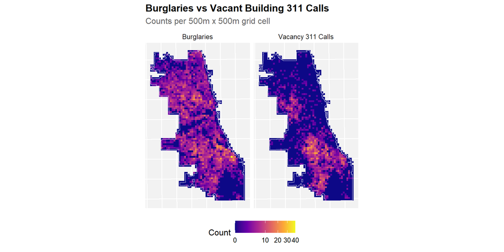

```r
library(tidyr)

fishnet_long <- fishnet %>%
tidyr::pivot_longer(
cols = c(countBurglaries, countVacancy),
names_to  = "type",
values_to = "count"
)

ggplot(fishnet_long) +
geom_sf(aes(fill = count), color = NA) +
geom_sf(data = chicagoBoundary, fill = NA, color = "white", linewidth = 0.3) +
scale_fill_viridis_c(
name   = "Count",
option = "plasma",
trans  = "sqrt",
na.value = "grey95"
) +
facet_wrap(
~ type,
labeller = as_labeller(c(
countBurglaries = "Burglaries",
countVacancy    = "Vacancy 311 Calls"
))
) +
labs(
title    = "Burglaries vs Vacant Building 311 Calls",
subtitle = "Counts per 500m x 500m grid cell"
) +
theme_crime()
```

## Spatial Features

In this section, spatial features will be calculated based on the predictor variable (Vacancy Counts). This will allow the creation of a spatial model that predicts burglary likelihood in fishnet grid squares.

### K-Nearest Neighbor

```r
# centroids of grid cells
fishnet_centroids <- st_centroid(fishnet)

# coords for knn
vac_coords <- st_coordinates(vacant_2017)
grid_coords <- st_coordinates(fishnet_centroids)

knn_vac <- get.knnx(vac_coords, grid_coords, k = 3)

fishnet$vac_knn_mean <- rowMeans(knn_vac$nn.dist)
```

### Local Moran’s I

A Local Moran’s I test will reveal signifigant spatial clusters and outliers in the dataset. At the grid level, it takes one grid square’s values and compares it to those of its neighbor’s. This gives us a good idea of where clusters are located and to what degree they are spatially autocorrelated.

```r
library(spdep)

nrow(fishnet)
```

```
[1] 2458
```

```r
fishnet$countVacancy[is.na(fishnet$countVacancy)] <- 0

fishnet_sp <- as(fishnet, "Spatial")

# neighbors via polygons
nb <- poly2nb(fishnet_sp)
lw <- nb2listw(nb, style = "W", zero.policy = TRUE)

localMI <- localmoran(fishnet_sp$countVacancy, lw, zero.policy = TRUE)

summary(localMI[, 1])
```

```
    Min.  1st Qu.   Median     Mean  3rd Qu.     Max.
-0.92012  0.07425  0.18898  0.59145  0.22723 27.41363
```

```r
summary(localMI[, 5])
```

```
   Min. 1st Qu.  Median    Mean 3rd Qu.    Max.
 0.0000  0.1768  0.2613  0.2952  0.3702  0.9898
```

```r
library(spdep)

fishnet$countVacancy[is.na(fishnet$countVacancy)] <- 0

fishnet_sp <- as(fishnet, "Spatial")

nb <- poly2nb(fishnet_sp)
lw <- nb2listw(nb, style = "W", zero.policy = TRUE)

localMI <- localmoran(
  fishnet_sp$countVacancy,
  lw,
  zero.policy = TRUE
)

summary(localMI[, 1])  # I values
```

```
    Min.  1st Qu.   Median     Mean  3rd Qu.     Max.
-0.92012  0.07425  0.18898  0.59145  0.22723 27.41363
```

```r
summary(localMI[, 5])  # p-values
```

```
   Min. 1st Qu.  Median    Mean 3rd Qu.    Max.
 0.0000  0.1768  0.2613  0.2952  0.3702  0.9898
```

```r
mean_vac <- mean(fishnet$countVacancy, na.rm = TRUE)

fishnet <- fishnet %>%
  mutate(
    vac_localI   = localMI[, 1],
    vac_p_value  = localMI[, 5],
    vac_sig      = vac_p_value < 0.05,
    vac_moran_class = case_when(
      !vac_sig ~ "Not Significant",
      vac_localI > 0 & countVacancy >  mean_vac ~ "High-High",
      vac_localI > 0 & countVacancy <= mean_vac ~ "Low-Low",
      vac_localI < 0 & countVacancy >  mean_vac ~ "High-Low",
      vac_localI < 0 & countVacancy <= mean_vac ~ "Low-High",
      TRUE ~ "Not Significant"
    )
  )

cat("✓ Calculated Local Moran's I for vacancy counts\n")
```

```
✓ Calculated Local Moran's I for vacancy counts
```

```r
table(fishnet$vac_moran_class)
```

```
      High-High        Low-High Not Significant
            318              43            2097
```

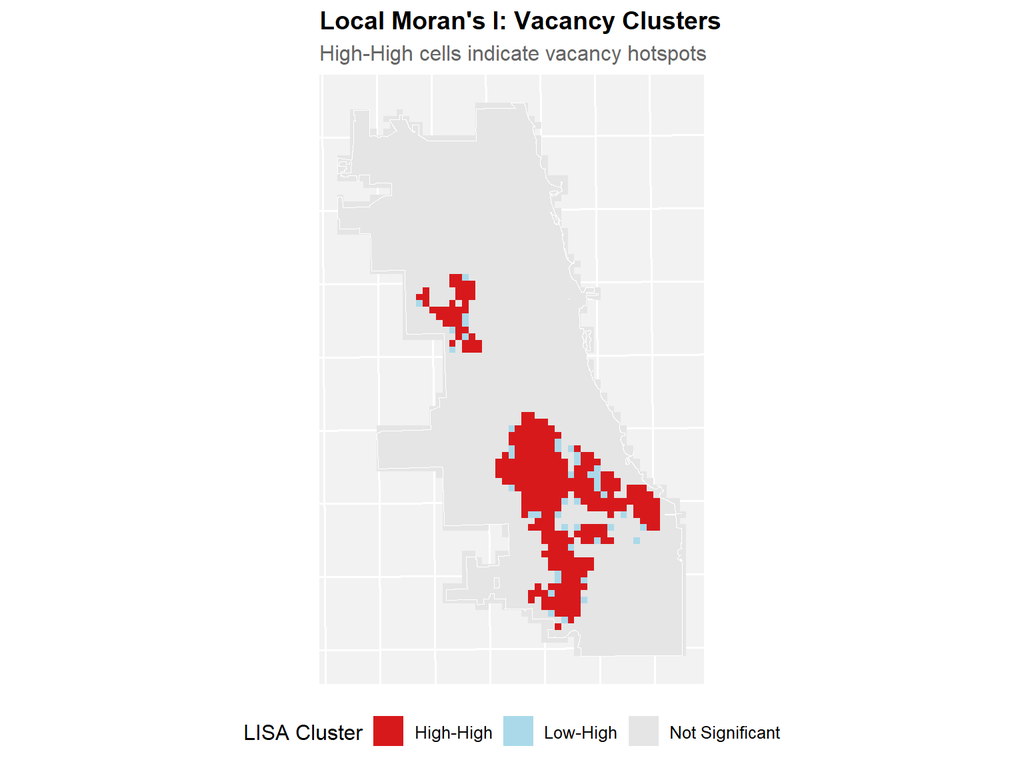

```r
ggplot() +
  geom_sf(
    data = fishnet,
    aes(fill = vac_moran_class),
    color = NA
  ) +
  geom_sf(
    data = chicagoBoundary,
    fill = NA,
    color = "white",
    linewidth = 0.3
  ) +
  scale_fill_manual(
    values = c(
      "High-High"       = "#d7191c",
      "Low-Low"         = "#2c7bb6",
      "High-Low"        = "#fdae61",
      "Low-High"        = "#abd9e9",
      "Not Significant" = "grey90"
    ),
    name = "LISA Cluster"
  ) +
  labs(
    title    = "Local Moran's I: Vacancy Clusters",
    subtitle = "High-High cells indicate vacancy hotspots"
  ) +
  theme_crime()
```

```r
# In this chunk I am gettings the distance to centroids of high high hotspots and calculating distance to hotspot for all grid squares
hotspots <- fishnet %>%
  filter(vac_moran_class == "High-High") %>%
  st_centroid()

if (nrow(hotspots) > 0) {

  grid_centroids <- st_centroid(fishnet)

  fishnet <- fishnet %>%
    mutate(
      dist_to_vac_hotspot = as.numeric(
        st_distance(grid_centroids, hotspots %>% st_union())
      )
    )

  cat("✓ Calculated distance to vacancy hot spots\n")
  cat("  - Number of High-High hotspot cells:", nrow(hotspots), "\n")

} else {

  fishnet <- fishnet %>%
    mutate(dist_to_vac_hotspot = NA_real_)

  cat("⚠ No significant vacancy hot spots found; dist_to_vac_hotspot set to NA\n")
}
```

```
✓ Calculated distance to vacancy hot spots
  - Number of High-High hotspot cells: 318
```

Running a local Moran’s I on the vacancy count of buildings compares the values of cells to those around it. The results show that there is significant spatial autocorrelation and hot spots of vacant buildings across the city. This is expected as areas with vacant buildings more likely to be surrounded by similar building makeup.This validates to use of a spatial model for predicting other behavior like burglaries as spatial clusters must be accounted for in the model.

## Count Regression

```r
fishnet <- fishnet %>%
  mutate(
    vac_knn_miles      = vac_knn_mean / 5280,           # convert feet → miles
    dist_hotspot_miles = dist_to_vac_hotspot / 5280,
    vac_localI_log     = log1p(pmax(vac_localI, 0))     # log(1 + positive I)
  )
```

```r
fishnet <- st_join(
  fishnet,
  policeDistricts,
  join = st_within,
  left = TRUE
)

# keep only fishnet cells that fall inside a district
fishnet <- fishnet %>%
  filter(!is.na(District))
```

```r
district_df <- fishnet %>%
  st_drop_geometry() %>%
  group_by(District) %>%
  summarize(
    countBurglaries    = sum(countBurglaries,   na.rm = TRUE),
    countVacancy       = sum(countVacancy,      na.rm = TRUE),
    vac_knn_miles      = mean(vac_knn_miles,    na.rm = TRUE),
    vac_localI_log     = mean(vac_localI_log,   na.rm = TRUE),
    dist_hotspot_miles = mean(dist_hotspot_miles, na.rm = TRUE)
  ) %>%
  ungroup()

district_df
```

```
# A tibble: 22 × 6
   District countBurglaries countVacancy vac_knn_miles vac_localI_log
   <chr>              <int>        <dbl>         <dbl>          <dbl>
 1 1                     75            0        0.285           0.199
 2 10                   228          129        0.0806          0.220
 3 11                   212          192        0.0430          0.600
 4 12                   371           37        0.102           0.107
 5 14                   259           22        0.110           0.116
 6 15                   151           76        0.0580          0.208
 7 16                   204           24        0.193           0.163
 8 17                   220           18        0.185           0.157
 9 18                   114            6        0.166           0.162
10 19                   233           12        0.224           0.167
# ℹ 12 more rows
# ℹ 1 more variable: dist_hotspot_miles <dbl>
```

```r
summary(district_df)
```

```
   District         countBurglaries  countVacancy   vac_knn_miles
 Length:22          Min.   : 59.0   Min.   :  0.0   Min.   :0.02400
 Class :character   1st Qu.:206.0   1st Qu.: 19.0   1st Qu.:0.07462
 Mode  :character   Median :246.0   Median : 70.0   Median :0.10599
                    Mean   :273.3   Mean   :131.1   Mean   :0.12317
                    3rd Qu.:356.5   3rd Qu.:191.8   3rd Qu.:0.17557
                    Max.   :719.0   Max.   :537.0   Max.   :0.28483
 vac_localI_log   dist_hotspot_miles
 Min.   :0.0760   Min.   :0.003642
 1st Qu.:0.1625   1st Qu.:0.170057
 Median :0.1887   Median :0.563503
 Mean   :0.3304   Mean   :0.708496
 3rd Qu.:0.2799   3rd Qu.:1.213993
 Max.   :1.8775   Max.   :2.224362
```

```r
model_pois_dist <- glm(
  countBurglaries ~ countVacancy + vac_knn_miles +
    vac_localI_log + dist_hotspot_miles,
  family = poisson(link = "log"),
  data   = district_df
)

summary(model_pois_dist)
```

```
Call:
glm(formula = countBurglaries ~ countVacancy + vac_knn_miles +
    vac_localI_log + dist_hotspot_miles, family = poisson(link = "log"),
    data = district_df)

Coefficients:
                     Estimate Std. Error z value             Pr(>|z|)
(Intercept)         5.7530471  0.0418501 137.468 < 0.0000000000000002 ***
countVacancy        0.0020534  0.0001543  13.309 < 0.0000000000000002 ***
vac_knn_miles      -0.9774972  0.4034475  -2.423             0.015399 *
vac_localI_log     -0.6330237  0.0551273 -11.483 < 0.0000000000000002 ***
dist_hotspot_miles -0.1742244  0.0472367  -3.688             0.000226 ***
---
Signif. codes:  0 '***' 0.001 '**' 0.01 '*' 0.05 '.' 0.1 ' ' 1

(Dispersion parameter for poisson family taken to be 1)

    Null deviance: 1550.0  on 21  degrees of freedom
Residual deviance: 1063.5  on 17  degrees of freedom
AIC: 1234.3

Number of Fisher Scoring iterations: 5
```

```r
library(MASS)

model_nb_dist <- glm.nb(
  countBurglaries ~ countVacancy + vac_knn_miles +
    vac_localI_log + dist_hotspot_miles,
  data = district_df
)

summary(model_nb_dist)
```

```
Call:
glm.nb(formula = countBurglaries ~ countVacancy + vac_knn_miles +
    vac_localI_log + dist_hotspot_miles, data = district_df,
    init.theta = 5.615096364, link = log)

Coefficients:
                    Estimate Std. Error z value            Pr(>|z|)
(Intercept)         5.839427   0.298992  19.530 <0.0000000000000002 ***
countVacancy        0.002420   0.001264   1.914              0.0556 .
vac_knn_miles      -1.764872   2.467971  -0.715              0.4745
vac_localI_log     -0.786600   0.417500  -1.884              0.0596 .
dist_hotspot_miles -0.166564   0.284755  -0.585              0.5586
---
Signif. codes:  0 '***' 0.001 '**' 0.01 '*' 0.05 '.' 0.1 ' ' 1

(Dispersion parameter for Negative Binomial(5.6151) family taken to be 1)

    Null deviance: 34.501  on 21  degrees of freedom
Residual deviance: 22.657  on 17  degrees of freedom
AIC: 278.94

Number of Fisher Scoring iterations: 1

              Theta:  5.62
          Std. Err.:  1.69

 2 x log-likelihood:  -266.944
```

```r
# Compare model fit with AIC
AIC(model_pois_dist, model_nb_dist)
```

```
                df       AIC
model_pois_dist  5 1234.2538
model_nb_dist    6  278.9444
```

### Analysis

Using a Poisson Regression model as well as a Negative Binomial REgression Model, I was able to compare the effectiveness of each and compare the results. The Negative Binomial model provides a much better fit than the Poisson regression (AIC 278.9 vs 1234.3), indicating strong overdispersion in district-level burglary counts.

### Poisson

In the Poisson Regression, All four predictors are statistically significant at 0.05:

countVacancy: 0.00205 (p < 2e-16)

vac_knn_miles: -0.98 (p ≈ 0.015)

vac_localI_log: -0.63 (p < 2e-16)

dist_hotspot_miles: -0.17 (p ≈ 0.0002)

##### For countVacancy:

Per 1 additional vacancy call: exp(0.0020534) ≈ 1.0021 → about a 0.2% increase in expected burglaries.

Per +100 vacancy calls (more interpretable at district level): exp(0.0020534 * 100) ≈ 1.23 → about a 23% increase in expected burglaries.

##### For vac_knn_miles (avg distance to 3 nearest vacant buildings):

Coefficient ≈ -0.98 → exp(-0.98) ≈ 0.38

So, if the average distance to nearby vacancy increases by 1 mile, expected burglaries drop by about 62%, all else equal. That matches the idea that burglaries concentrate where vacancies are dense/nearby.

##### For dist_hotspot_miles (distance to nearest vacancy hotspot):

Coefficient ≈ -0.17 → exp(-0.17) ≈ 0.84

A 1-mile increase in distance from a vacancy hotspot is associated with about a 16% decrease in expected burglaries.

##### Over Dispersion

Residual deviance of 1063.5 and Degrees of freedom equal to 17 indicates that deviance was significantly larger than expected in this model. Due to this, it is statistically invalid and not suitable for this analysis.

#### Negative Binomial

The NB model saw residual deviance 22.7 on 17 df → deviance/df ≈ 1.33 which is much improved from the Poisson model.

countVacancy: 0.00242 (p ≈ 0.056) → borderline significant

vac_knn_miles: -1.76 (p ≈ 0.47) → not significant

vac_localI_log: -0.79 (p ≈ 0.0596) → borderline

dist_hotspot_miles: -0.17 (p ≈ 0.56) → not significant

The model resulted in signifigance values that were much more conservative with only two (countVacancy and vac_localI_log) coming close to the desired signifigance level of p < 0.05. This reflects the small number of districts used in the analysis and signifigance issues with overdispersion.

## Spatial Cross Validation

```r
districts <- unique(district_df$District)

cv_results <- data.frame(
  District = numeric(),
  observed = numeric(),
  pred_pois = numeric(),
  pred_nb   = numeric()
)

for (d in districts) {

  train <- district_df %>% filter(District != d)

  test <- district_df %>% filter(District == d)

  model_pois <- glm(
    countBurglaries ~ countVacancy + vac_knn_miles +
      vac_localI_log + dist_hotspot_miles,
    family = poisson(),
    data = train
  )

  model_nb <- glm.nb(
    countBurglaries ~ countVacancy + vac_knn_miles +
      vac_localI_log + dist_hotspot_miles,
    data = train
  )

  pred_pois <- predict(model_pois, newdata = test, type = "response")
  pred_nb   <- predict(model_nb,   newdata = test, type = "response")

  cv_results <- rbind(
    cv_results,
    data.frame(
      District = d,
      observed = test$countBurglaries,
      pred_pois = pred_pois,
      pred_nb = pred_nb
    )
  )
}

cv_results
```

```
    District observed pred_pois  pred_nb
1          1       75  287.7346 278.4874
11        10      228  327.5765 341.1258
12        11      212  315.7615 327.8840
13        12      371  244.1872 244.7312
14        14      259  247.9473 246.1856
15        15      151  329.2441 344.8420
16        16      204  181.6786 166.2880
17        17      220  192.8991 178.6334
18        18      114  207.0464 195.5333
19        19      233  176.0517 149.7343
110        2      226  301.0557 314.0038
111       20       59  199.2158 187.8102
112       22      277  354.9466 350.9317
113       24      145  179.4385 166.0965
114       25      417  258.8420 263.7765
115        3      386  285.7230 292.7650
116        4      451  542.1779 689.5797
117        5      299  427.6587 468.1149
118        6      370  353.0404 376.2045
119        7      316  165.8970 139.4345
120        8      719  244.6187 243.3168
121        9      280  334.9892 354.0948
```

```r
rmse_pois <- sqrt(mean((cv_results$observed - cv_results$pred_pois)^2))
rmse_nb   <- sqrt(mean((cv_results$observed - cv_results$pred_nb)^2))

mae_pois <- mean(abs(cv_results$observed - cv_results$pred_pois))
mae_nb   <- mean(abs(cv_results$observed - cv_results$pred_nb))

cor_pois <- cor(cv_results$observed, cv_results$pred_pois)
cor_nb   <- cor(cv_results$observed, cv_results$pred_nb)

c(
  RMSE_Poisson = rmse_pois,
  MAE_Poisson  = mae_pois,
  COR_Poisson  = cor_pois,
  RMSE_NB = rmse_nb,
  MAE_NB  = mae_nb,
  COR_NB  = cor_nb
)
```

```
RMSE_Poisson  MAE_Poisson  COR_Poisson      RMSE_NB       MAE_NB       COR_NB
 146.2279307  110.6345699    0.2722330  157.9624533  123.0837758    0.2966045
```

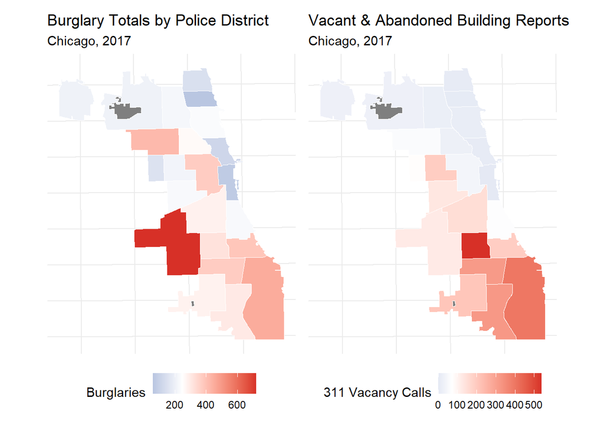

```r
district_map <- policeDistricts %>%
  left_join(district_df, by = "District")

map_burg <- ggplot(district_map) +
  geom_sf(aes(fill = countBurglaries), color = "white", size = 0.3) +
  scale_fill_gradient2(
    low = "#4575b4",   # cool blue
    mid = "white",
    high = "#d73027",  # hot red
    midpoint = median(district_map$countBurglaries, na.rm = TRUE),
    name = "Burglaries"
  ) +
  labs(
    title = "Burglary Totals by Police District",
    subtitle = "Chicago, 2017"
  ) +
  theme_minimal() +
  theme(
    legend.position = "bottom",
    axis.text = element_blank(),
    axis.ticks = element_blank()
  )

map_vac <- ggplot(district_map) +
  geom_sf(aes(fill = countVacancy), color = "white", size = 0.3) +
  scale_fill_gradient2(
    low = "#4575b4",
    mid = "white",
    high = "#d73027",
    midpoint = median(district_map$countVacancy, na.rm = TRUE),
    name = "311 Vacancy Calls"
  ) +
  labs(
    title = "Vacant & Abandoned Building Reports",
    subtitle = "Chicago, 2017"
  ) +
  theme_minimal() +
  theme(
    legend.position = "bottom",
    axis.text = element_blank(),
    axis.ticks = element_blank()
  )

map_burg + map_vac
```

## Findings and Conclusion

### Findings

This study found that vacancy counts do correlate with burglary patterns. Hotspot vacancy clusters (High–High LISA) aligned with elevated burglary risk particullary in the south side of Chicago. The Negative Binomial model produced the best overall fit (AIC ≈ 279) but did not yield signifigance levels that showed strong correlation.

### Limitations

Both models struggled to capture variation across large administrative units (districts). This means that vacancy alone cannot explain burglary. Missing demographic information such as police behavior, reporting frequency, and city planning data would greatly increase the signifigance of these models.The small number of districts and their large size created limitations in how well the models could navigate the relationships between these variables. The study would benefit from utilizing smaller geographic areas like police beats or neighborhoods to predict crime.

### Conclusion

Vacancy information is useful for identifying areas of elevated burglary risk, but not sufficient for accurate district-level prediction. For better performance, more detailed demographic and economic variables could be incorporated to fill in missing factors in predicting crime.